# PROXIOME EXPERIMENT SUMMARY

v0.21.0

Published

June 11, 2026

**Samples**

### Sample description

| Pool | Sample Alias | Sample name | Condition | % of pool |
| --- | --- | --- | --- | --- |
| pool1 | S1 | sample1 | unstim | 47.37 |
| pool1 | S2 | sample2 | stim | 52.63 |
| pool2 | S3 | sample3 | unstim | 47.62 |
| pool2 | S4 | sample4 | stim | 52.38 |

**Quality metrics**

### Key metrics

**Hash pool metrics**

| Pool ID | Total reads [M] | Valid reads [M] | Graph Nodes [M] | Graph Edges [M] | Graph node saturation [%] | Graph edge saturation [%] | Valid reads saturation [%] | % Valid reads | % Graph reads | % Denoised UMIs | Total denoised UMIs [M] | % Crossing edges (Initial) | % Crossing edges (Refinement) | Number of cells in pool | % Sample called cells |
| --- | --- | --- | --- | --- | --- | --- | --- | --- | --- | --- | --- | --- | --- | --- | --- |
| pool1 | 0.31 | 0.31 | 0.02 | 0.04 | 92.16 | 85.67 | 85.66 | 99.88 | 90.69 | 3.24 | 0 | 1.2 | 0 | 40 | 95 |
| pool2 | 0.16 | 0.15 | 0.01 | 0.02 | 92.03 | 85.7 | 85.7 | 99.85 | 88.37 | 3.83 | 0 | 3.32 | 0 | 44 | 95.45 |

**Sample metrics**

| Sample ID | Number of cells in sample | Number of cells >10k nodes | Median isotype % counts | Median intracellular % counts | Median proteins per cell [k] | Median reads per cell [k] | Median mean coreness | Median % dangling nodes | Median % well connected nodes | Top 3 % counts | Top 5 % counts | Top 5 markers | % B2M hash purity | % CD298 hash purity | % CD98 hash purity | % hash counts |
| --- | --- | --- | --- | --- | --- | --- | --- | --- | --- | --- | --- | --- | --- | --- | --- | --- |
| S1 | 18 | 0 | 0.35 | 0 | 0.58 | 7.42 | 2.69 | 15.3 | 84.17 | 11.68 | 19.22 | OX40, NKp80, TCRVb5, IgM, CD45 | 99.21 | 100 | 100 | 4.42 |
| S2 | 20 | 0 | 0.34 | 0 | 0.58 | 7.43 | 2.68 | 15.56 | 83.99 | 11.73 | 19.34 | CD80, CD29, CD41, CD277, TCRVa7.2 | 100 | 100 | 100 | 4.16 |
| S3 | 20 | 0 | 0 | 0 | 0.24 | 3 | 2.67 | 16.14 | 82.59 | 21.02 | 34.73 | CD14, CD69, CD36, CD28, CD22 | 95 | 95 | 100 | 4.08 |
| S4 | 22 | 0 | 0.15 | 0 | 0.25 | 3.17 | 2.69 | 15.47 | 83.63 | 21.25 | 35.03 | CD14, CD36, EpCAM, CD69, CD48 | 100 | 95.45 | 100 | 4.51 |

### Sample hashing

The hash purity for an antibody is defined as the number of UMIs from the most common antibody hash divided by the sum of UMIs for all antibody hashes. For instance, if B2M-1 is the most common hash, the hash purity for B2M is the number of UMIs for B2M-1 divided by the sum of UMIs for all B2M hashes.

**Figure**

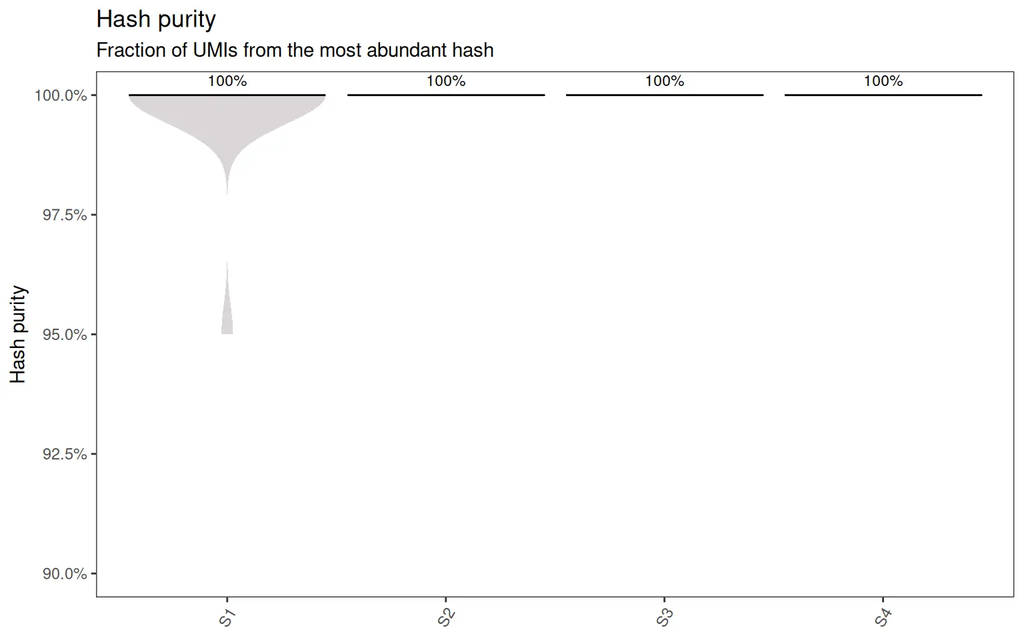

**Table**

| Sample ID | Hash purity B2M [%] | Hash purity CD298 [%] | Hash purity CD98 [%] | Fraction hash UMIs |
| --- | --- | --- | --- | --- |
| S1 | 99.21 | 100 | 100 | 4.42 |
| S2 | 100 | 100 | 100 | 4.16 |
| S3 | 95 | 95 | 100 | 4.08 |
| S4 | 100 | 95.45 | 100 | 4.51 |

**pool1**

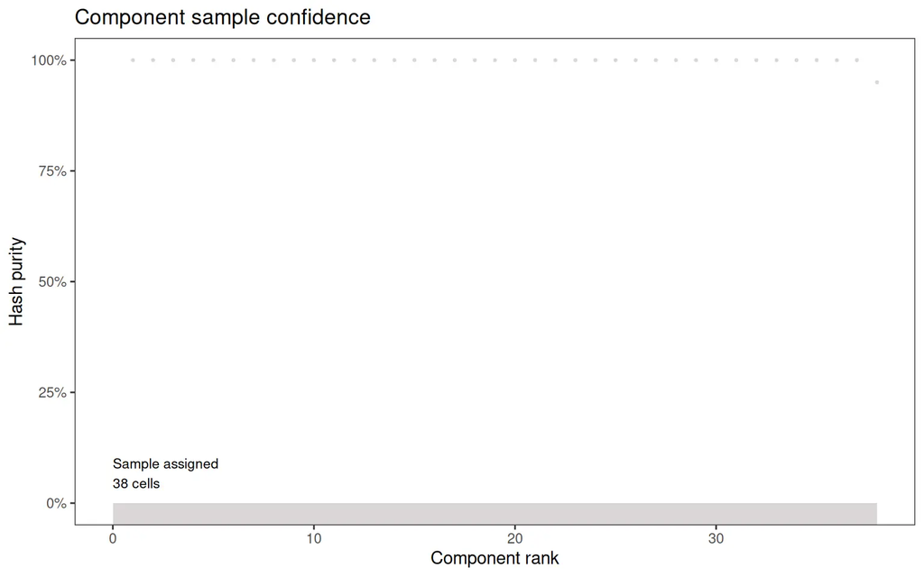

**pool2**

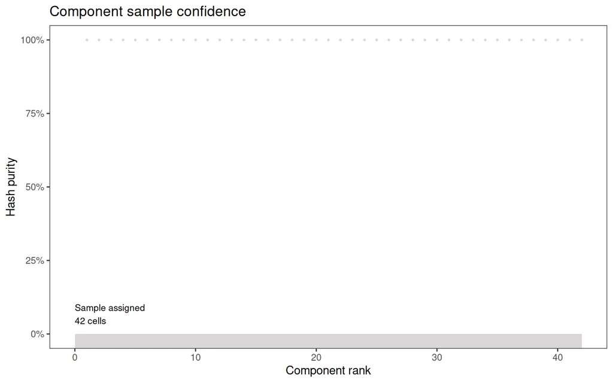

**S1**

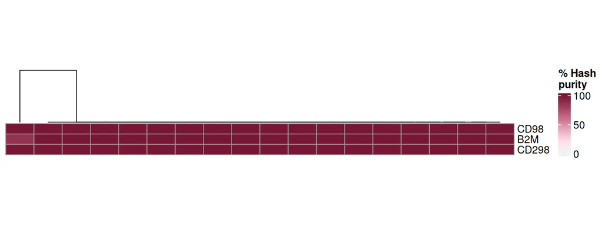

**S2**

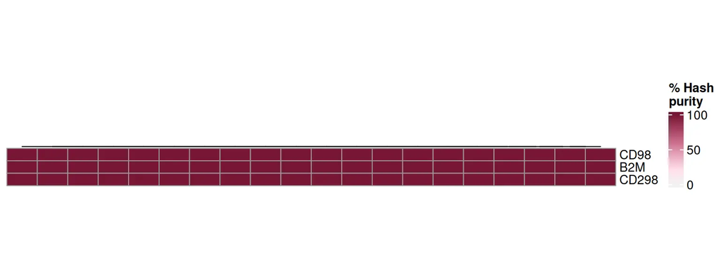

**S3**

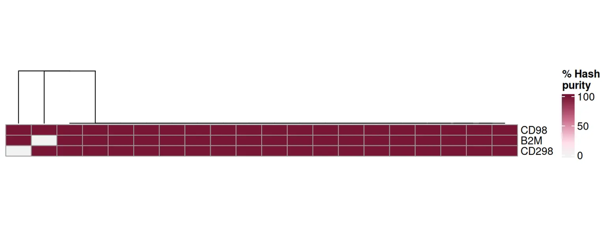

**S4**

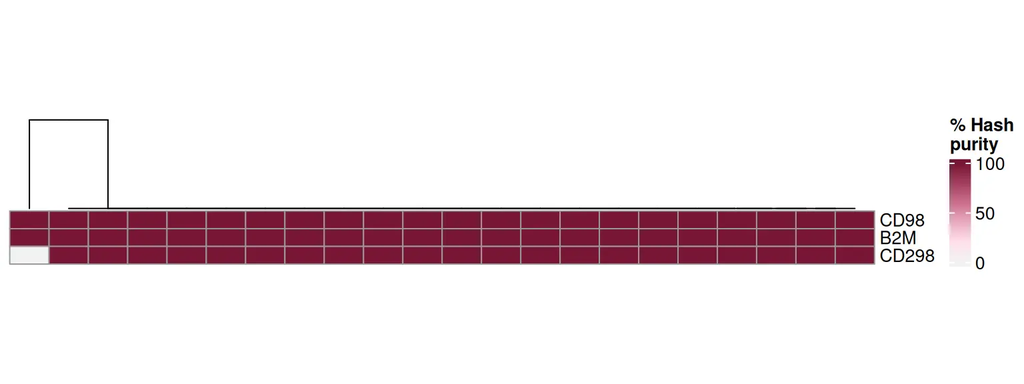

**S1**

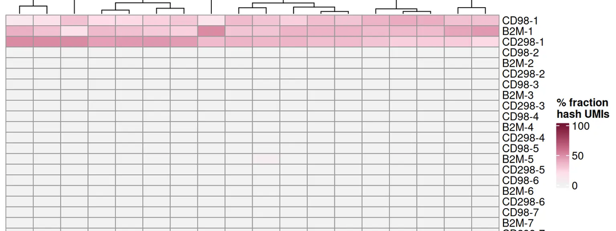

**S2**

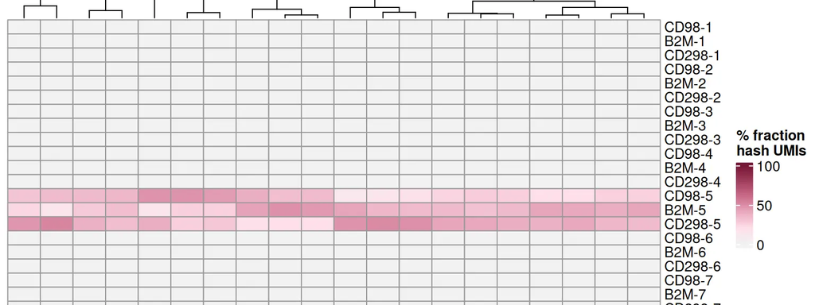

**S3**

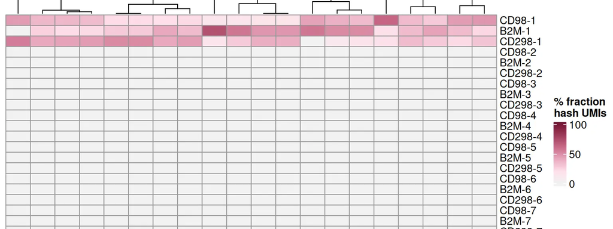

**S4**

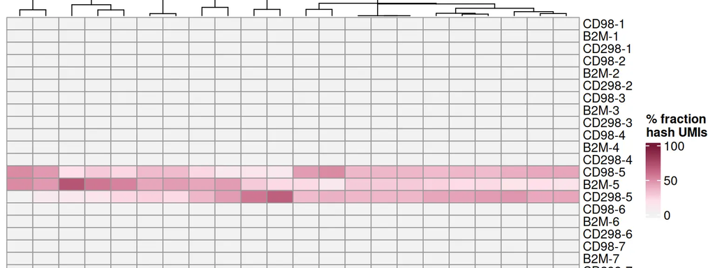

### Sequencing

#### Reads and molecules

Here we review the number of reads per stage of the `pixelator` pipeline, and the number of molecules that they are mapped to.

**Figure**

**pool1**

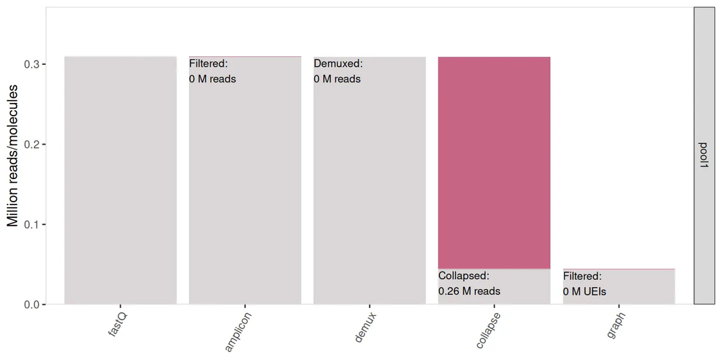

**pool2**

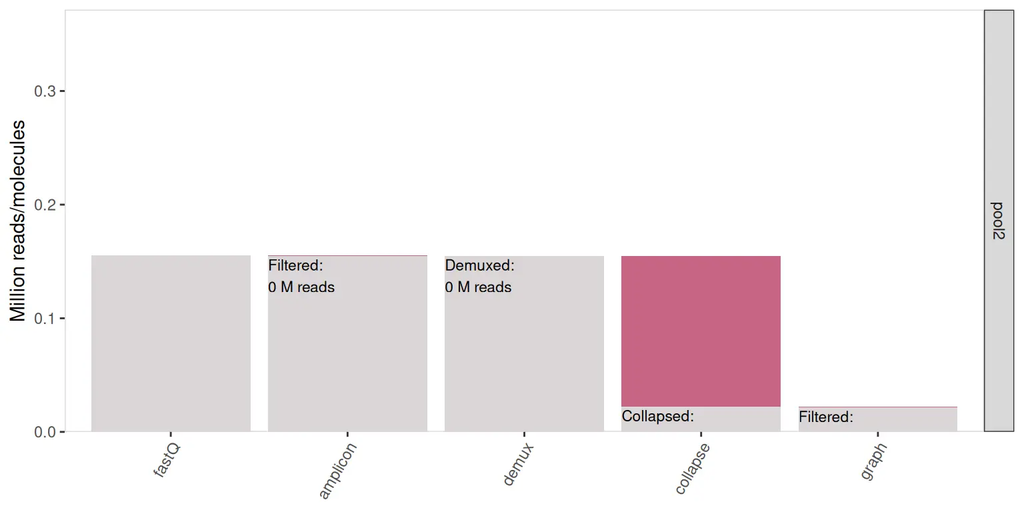

**Table**

| sample_alias | stage | output | filtered | % filtered |
| --- | --- | --- | --- | --- |
| pool1 | fastQ | 0.31 |  | NA % |
| pool1 | amplicon | 0.309 | 0 | 0 % |
| pool1 | demux | 0.309 | 0 | 0 % |
| pool1 | collapse | 0.044 | 0.265 | 85.76 % |
| pool1 | graph | 0.044 | 0.001 | 2.22 % |
| pool2 | fastQ | 0.155 |  | NA % |
| pool2 | amplicon | 0.155 | 0 | 0 % |
| pool2 | demux | 0.155 | 0 | 0 % |
| pool2 | collapse | 0.022 | 0.133 | 85.81 % |
| pool2 | graph | 0.021 | 0.001 | 4.55 % |

#### Sequencing saturation

Sequencing saturation is the fraction of a library’s complexity that has been captured through sequencing.

**S1**

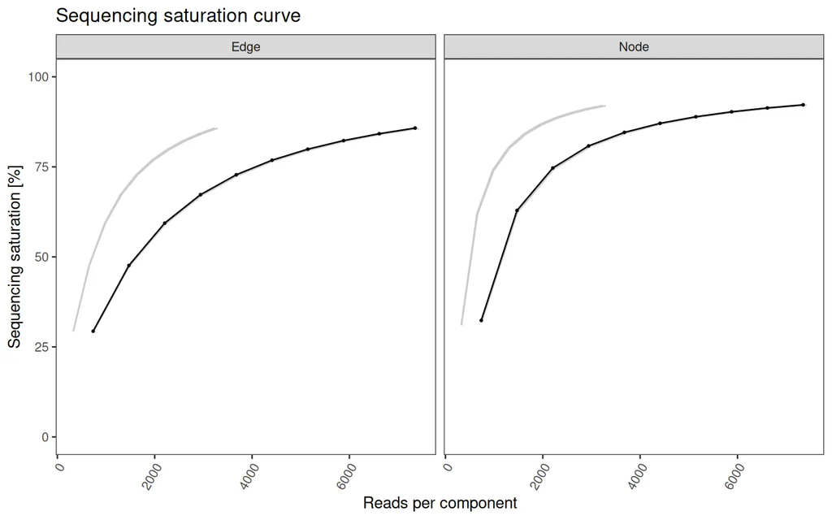

**S2**

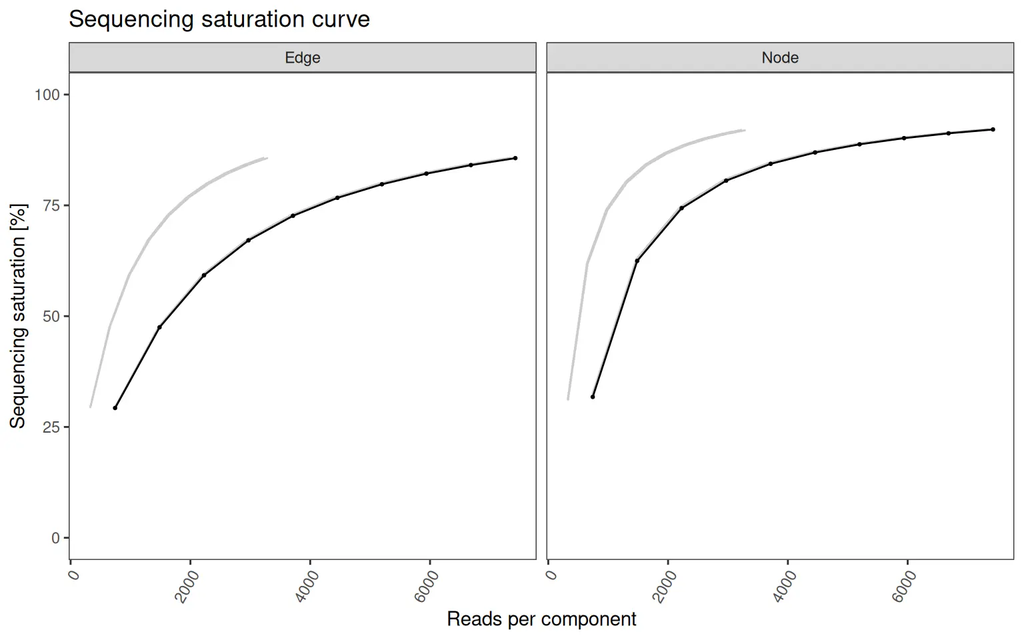

**S3**

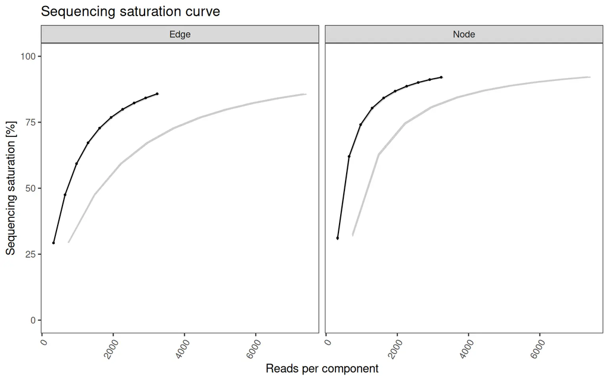

**S4**

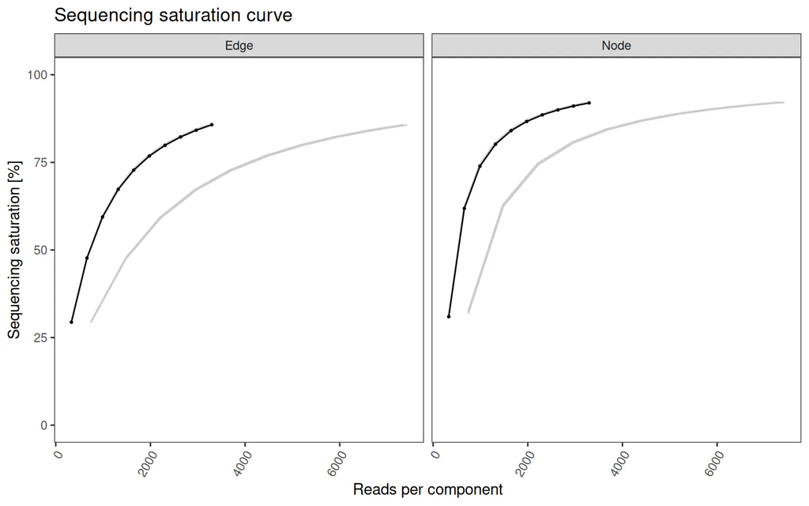

**Figure**

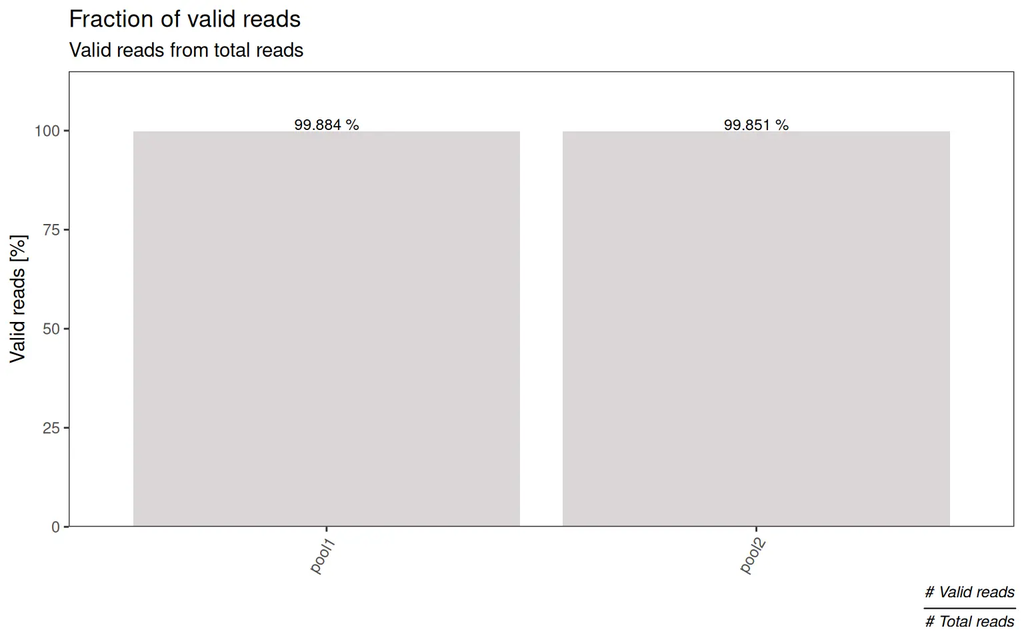

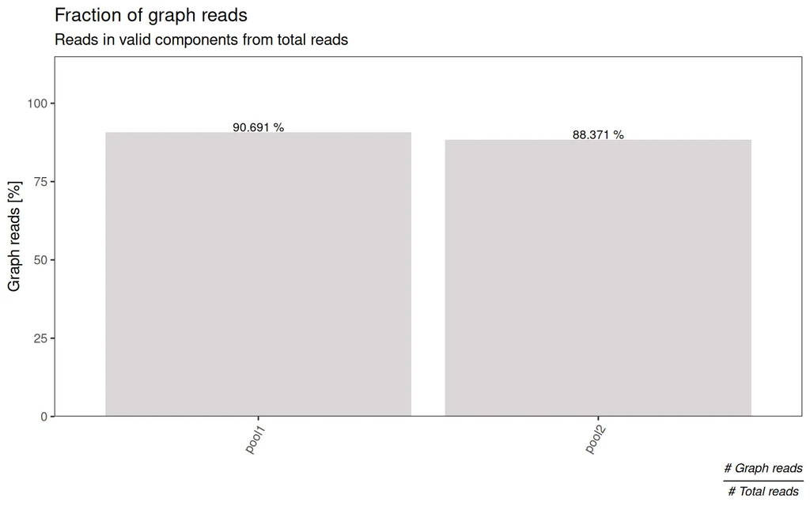

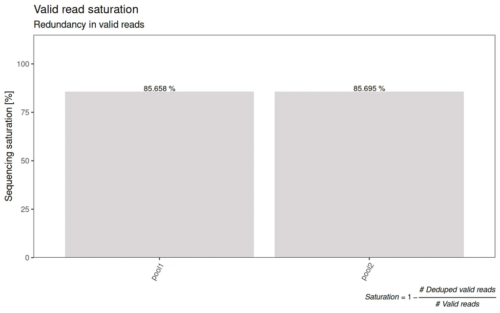

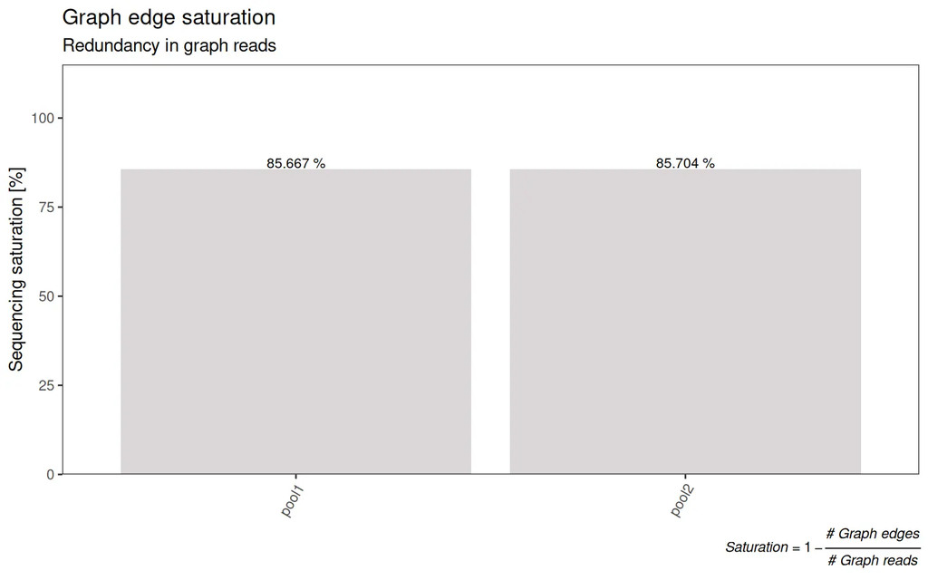

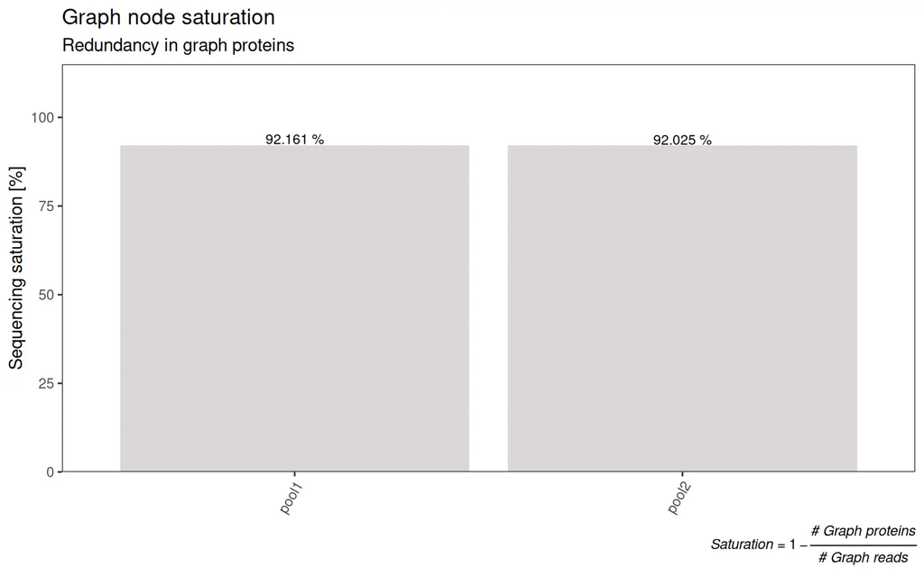

**Table**

| Sample ID | Protein molecules [M] | Total reads [M] | Valid reads [M] | Deduped valid reads [M] | Total edges [M] | Fraction valid reads [%] | Fraction graph reads [%] | Valid reads saturation [%] | Graph edge saturation [%] | Graph node saturation [%] |
| --- | --- | --- | --- | --- | --- | --- | --- | --- | --- | --- |
| pool1 | 0.022 | 0.31 | 0.309 | 0.044 | 0.04 | 99.884 | 90.691 | 85.658 | 85.667 | 92.161 |
| pool2 | 0.011 | 0.155 | 0.155 | 0.022 | 0.02 | 99.851 | 88.371 | 85.695 | 85.704 | 92.025 |

#### Reads per cell

**Figure**

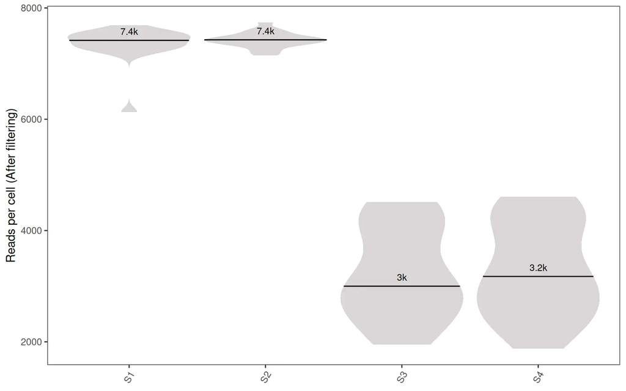

**Table**

| Sample ID | Median reads per cell [thousands] |
| --- | --- |
| S1 | 7.418 |
| S2 | 7.428 |
| S3 | 2.999 |
| S4 | 3.175 |

### Cell recovery

#### Number of components

**Figure**

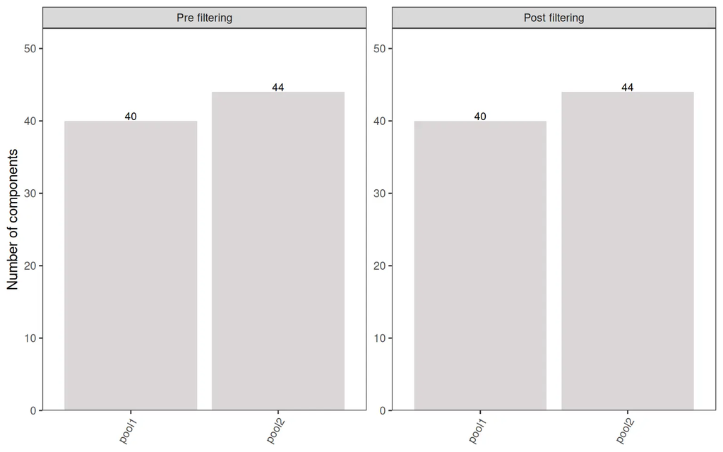

**Table**

| Sample ID | Min size threshold | Max size threshold |
| --- | --- | --- |
| pool1 | 100 |  |
| pool2 | 100 |  |

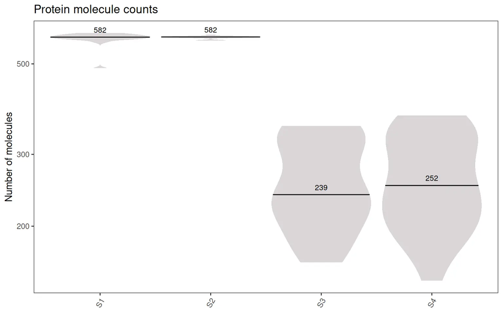

**Figure**

**Pools**

**pool1**

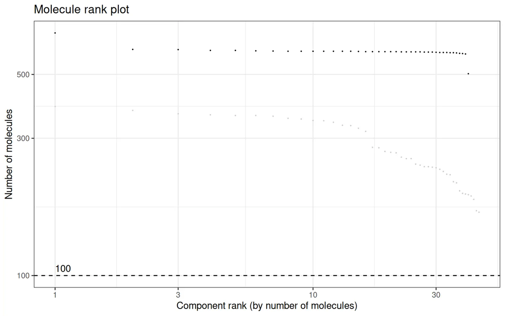

**pool2**

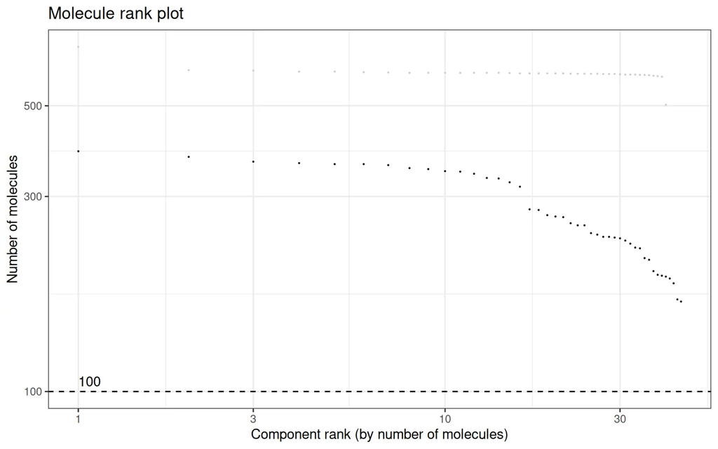

**Samples**

**S1**

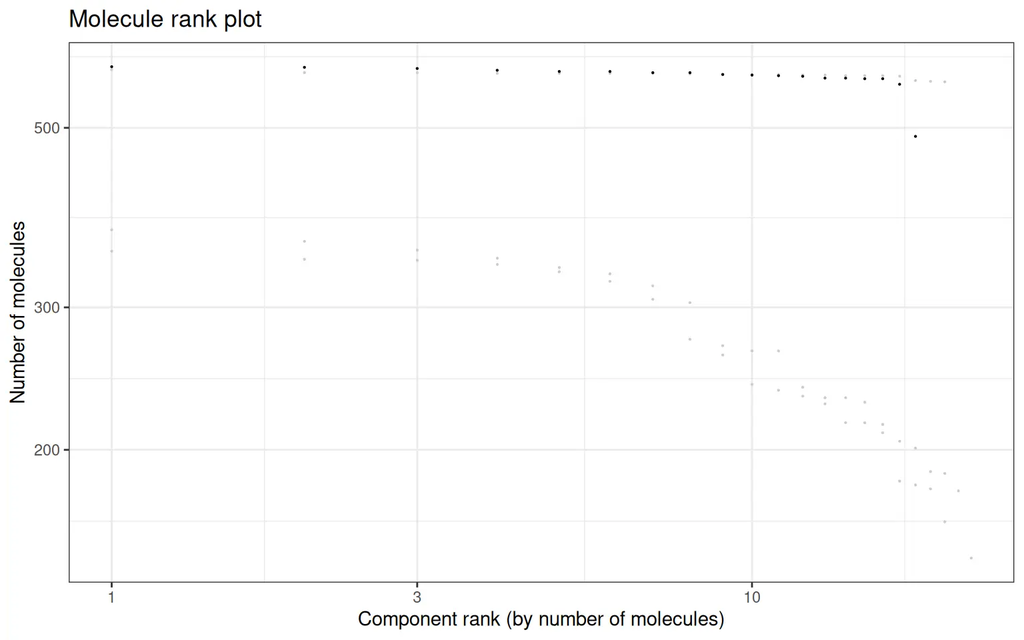

**S2**

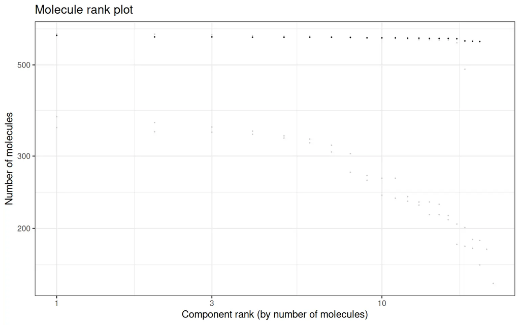

**S3**

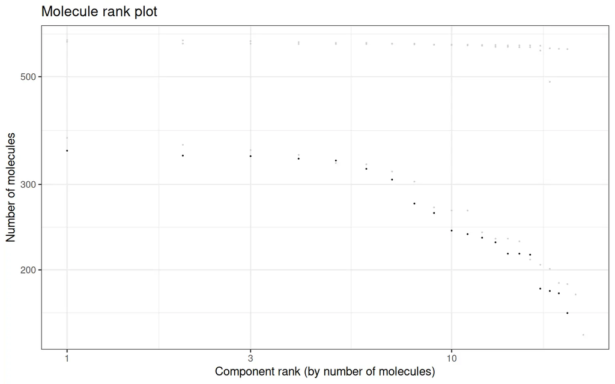

**S4**

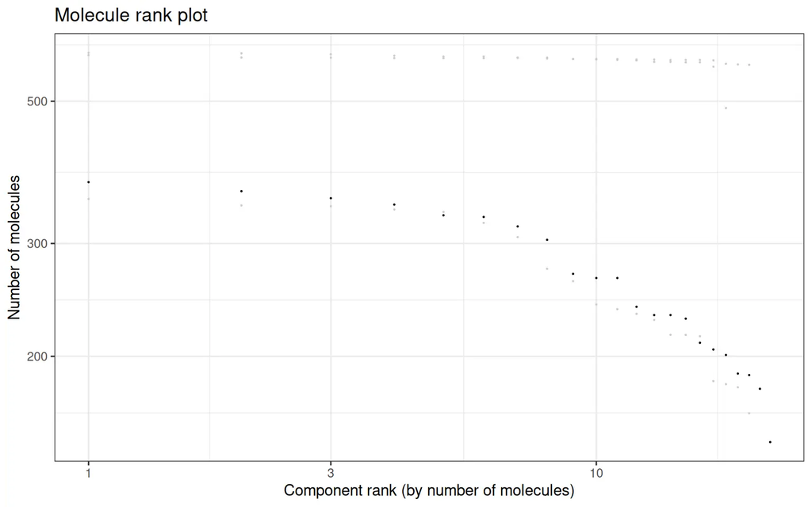

**Table**

| Sample ID | Before filtering | After filtering |
| --- | --- | --- |
| pool1 | 40 | 40 |
| pool2 | 44 | 44 |

#### Percent of nodes in largest component

**Figure**

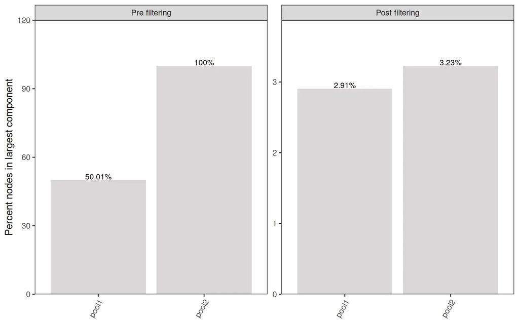

**Table**

| Sample ID | Before filtering | After filtering |
| --- | --- | --- |
| pool1 | 50.015 % | 2.906 % |
| pool2 | 100 % | 3.227 % |

### Graph metrics

#### Degree distribution

The distribution of degree in the collapsed unresolved graph.

**Figure**

**pool1**

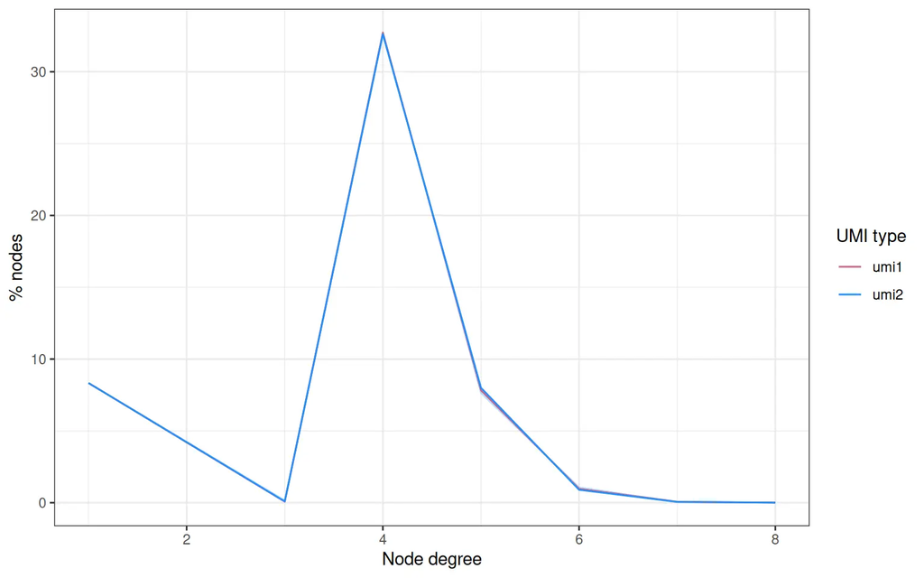

**pool2**

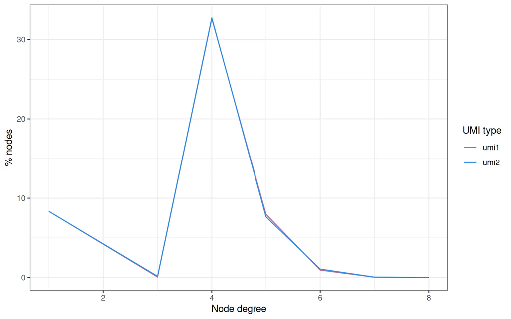

**Table**

| Sample ID | UMI type | Degree | #Nodes | %Nodes |
| --- | --- | --- | --- | --- |
| pool1 | umi1 | 1 | 1998 | 8.33 |
| pool1 | umi1 | 3 | 18 | 0.08 |
| pool1 | umi1 | 4 | 7849 | 32.72 |
| pool1 | umi1 | 5 | 1877 | 7.83 |
| pool1 | umi1 | 6 | 233 | 0.97 |
| pool1 | umi1 | 7 | 16 | 0.07 |
| pool1 | umi1 | 8 | 1 | 0 |
| pool1 | umi2 | 1 | 1998 | 8.33 |
| pool1 | umi2 | 3 | 22 | 0.09 |
| pool1 | umi2 | 4 | 7824 | 32.62 |

[output cut: 18 more lines]

#### A/B node degree

The mean degree of A and B nodes in the resolved graph components.

**Figure**

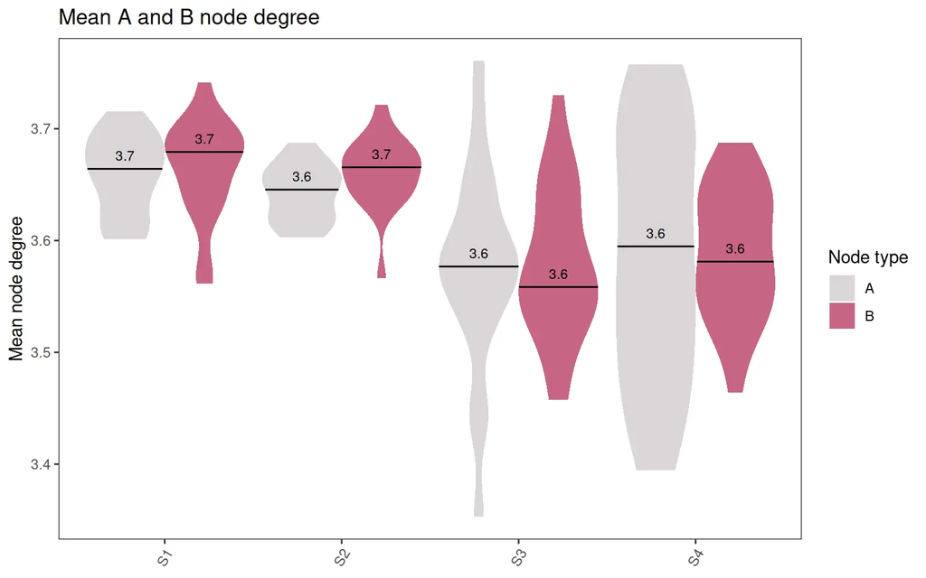

**Table**

| Sample ID | COa | COb |
| --- | --- | --- |
| S1 | 3.66 | 3.68 |
| S2 | 3.65 | 3.67 |
| S3 | 3.58 | 3.56 |
| S4 | 3.59 | 3.58 |

#### Crossing edges

In the `graph` stage of the `pixelator` pipeline, components corresponding to cells are identified by finding parts of the graph with high intraconnectivity. These components recovered from the graph by removing a low number of presumed random edges that are known as “crossing edges”.

**Figure**

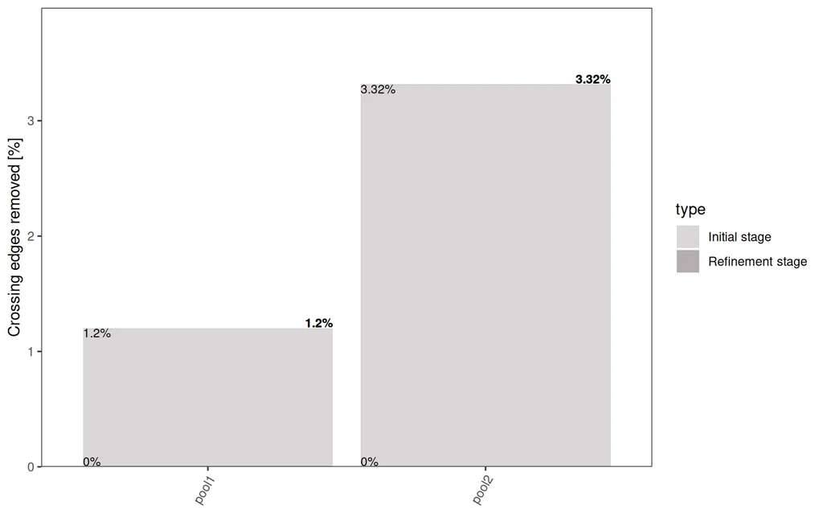

**Table**

| sample_alias | Total removed | Initial stage | Refinement stage |
| --- | --- | --- | --- |
| pool1 | 533 / 1.202 % | 533 / 1.202 % | 0 / 0 % |
| pool2 | 735 / 3.316 % | 735 / 3.316 % | 0 / 0 % |

#### k-coreness

k-coreness is a measure of the connectivity of a node in a graph. A node with a high k-coreness is well connected to other nodes in the graph.

**Figure**

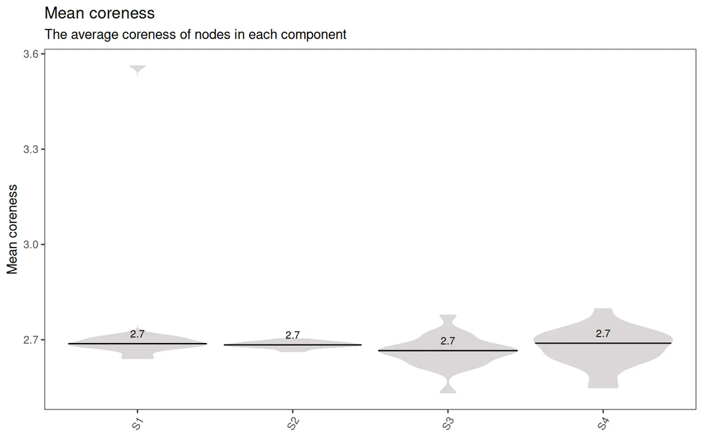

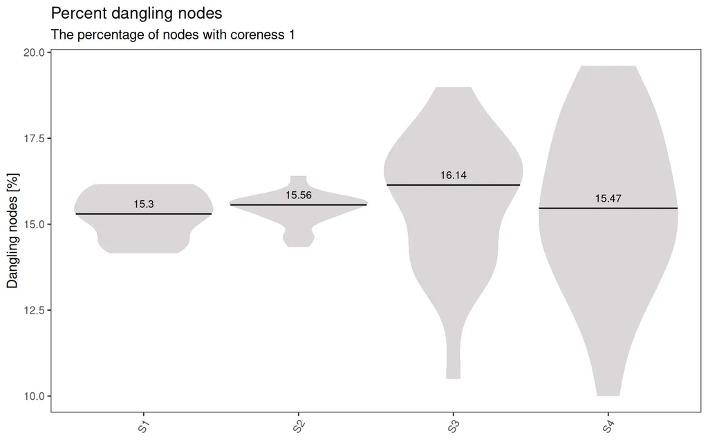

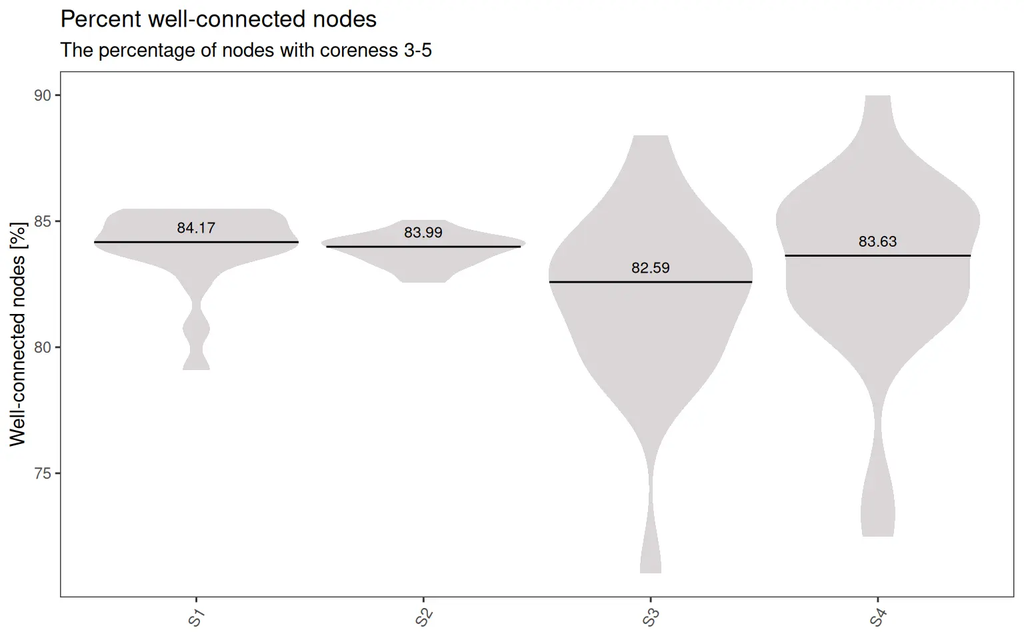

**Table**

| Sample ID | Median mean coreness | Median dangling nodes [%] | Median well connected nodes [%] |
| --- | --- | --- | --- |
| S1 | 2.69 | 15.3 | 84.17 |
| S2 | 2.68 | 15.56 | 83.99 |
| S3 | 2.67 | 16.14 | 82.59 |
| S4 | 2.69 | 15.47 | 83.63 |

**S1**

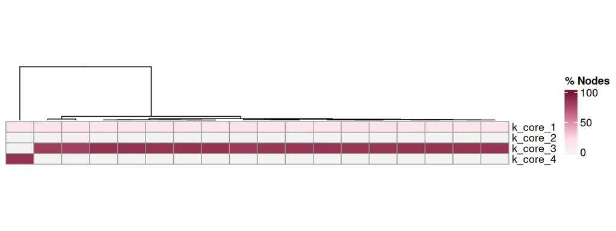

**S2**

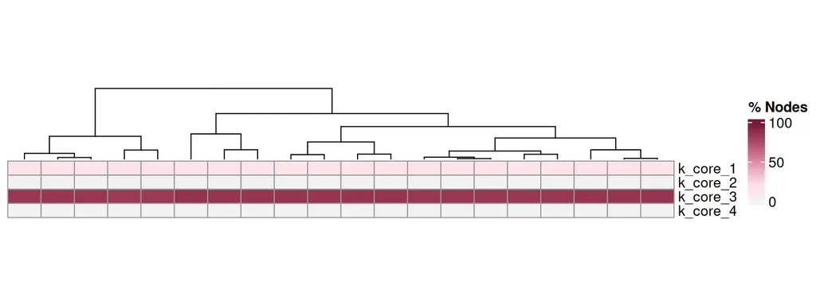

**S3**

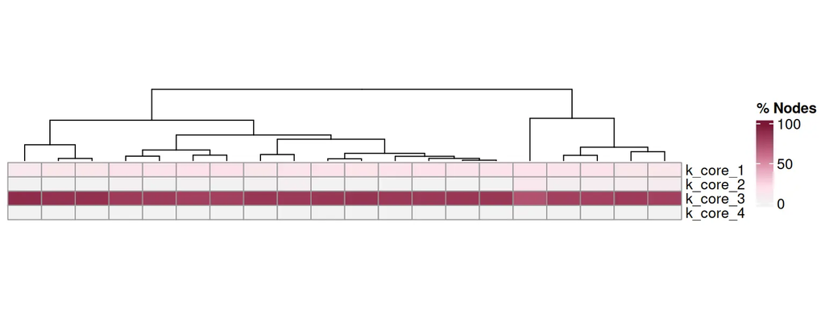

**S4**

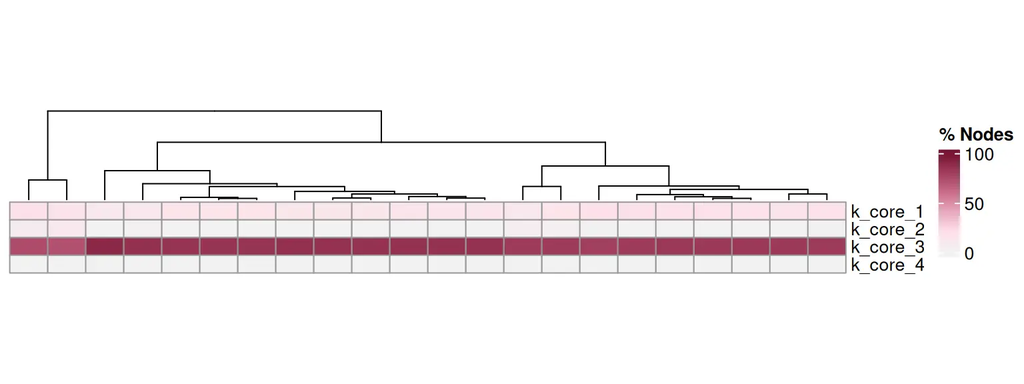

#### Denoising

Denoising removes low-connectivity graph nodes to improve data quality.

**Figure**

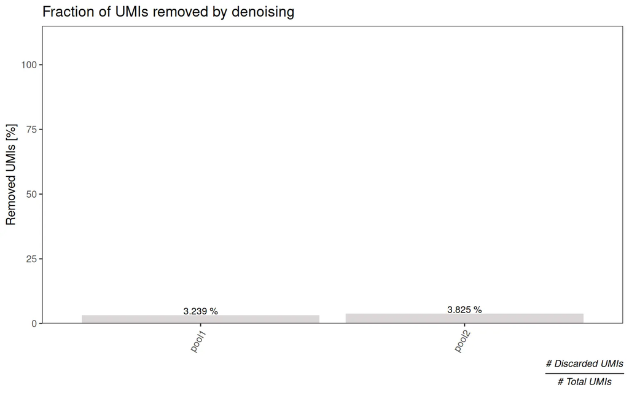

**Table**

| Sample ID | % Denoised UMIs | Total denoised UMIs [M] |
| --- | --- | --- |
| pool1 | 3.239 | 0.001 |
| pool2 | 3.825 | 0 |

**Figure**

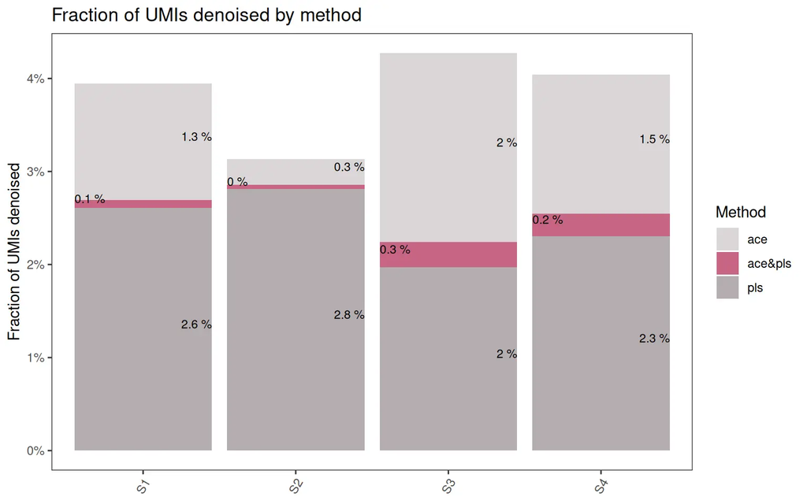

**Table**

| Sample ID | Denoising method | UMIs denoised | Fraction denoised [%] |
| --- | --- | --- | --- |
| S1 | ace | 130 | 1.251 |
| S1 | ace&pls | 9 | 0.087 |
| S1 | pls | 271 | 2.608 |
| S2 | ace | 32 | 0.275 |
| S2 | ace&pls | 5 | 0.043 |
| S2 | pls | 327 | 2.814 |
| S3 | ace | 105 | 2.03 |
| S3 | ace&pls | 14 | 0.271 |
| S3 | pls | 102 | 1.972 |
| S4 | ace | 86 | 1.492 |

[output cut: 2 more lines]

**Figure**

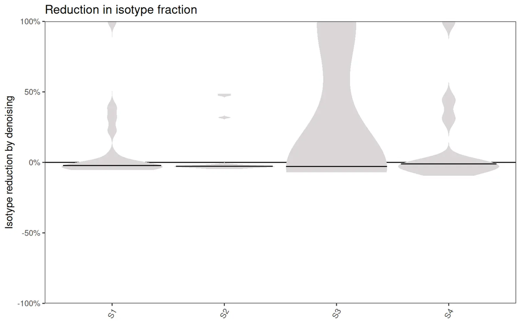

**Table**

[output not shown]

### Control markers

**Figure**

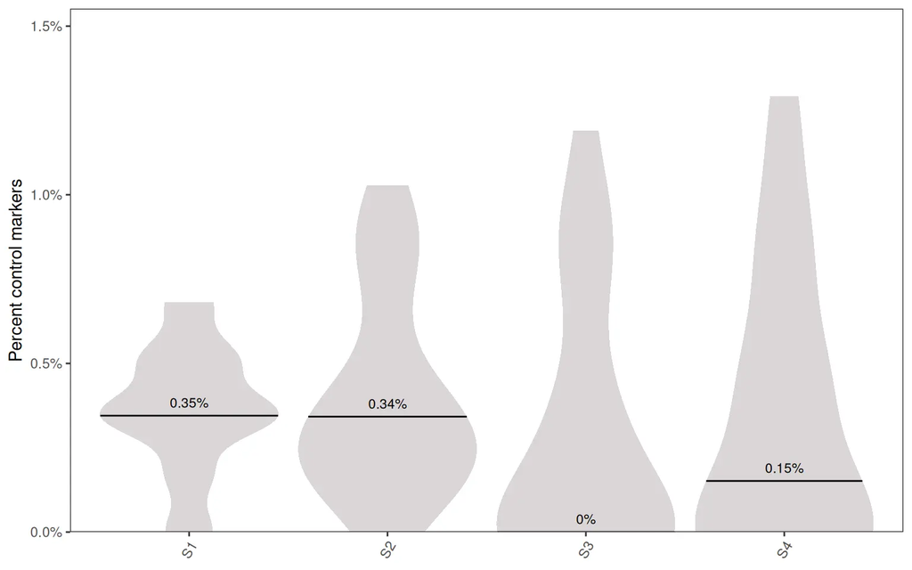

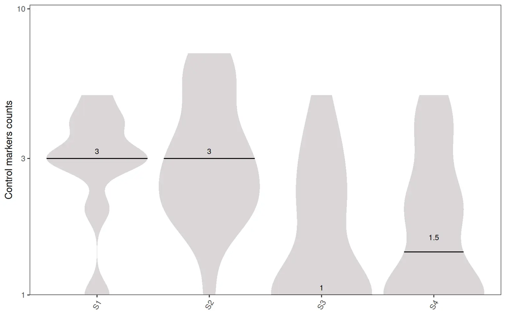

**Table**

| Sample ID | Median percent control markers | Median control markers counts |
| --- | --- | --- |
| S1 | 0.345 | 3 |
| S2 | 0.342 | 3 |
| S3 | 0 | 1 |
| S4 | 0.152 | 1.5 |

**Cell annotation**

### Dimensionality Reduction

**UMAP**

**Combined**

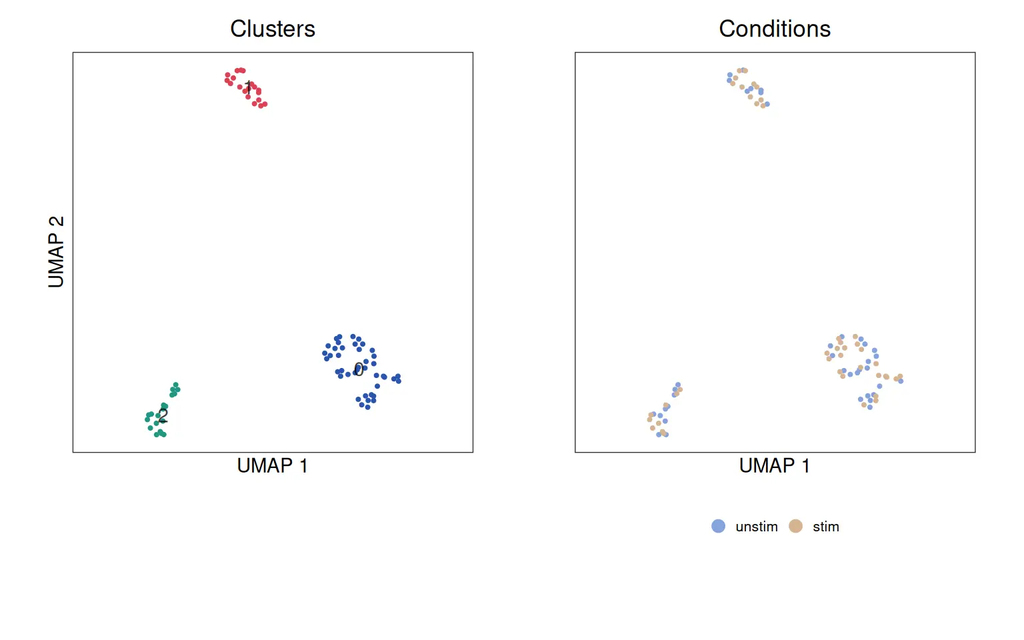

**Samplewise**

**S1**

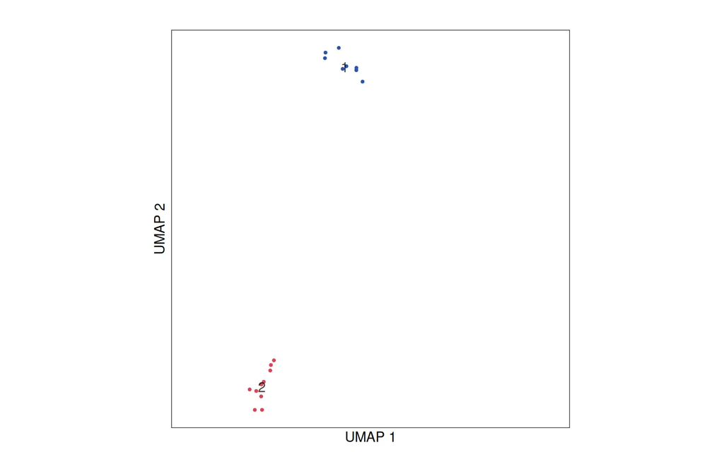

**S2**

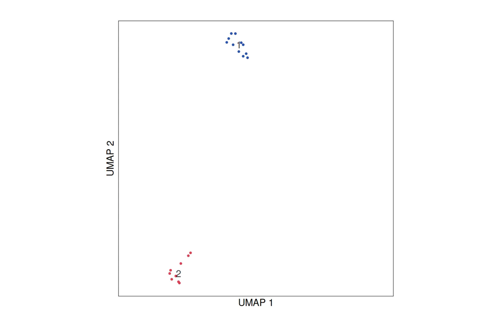

**S3**

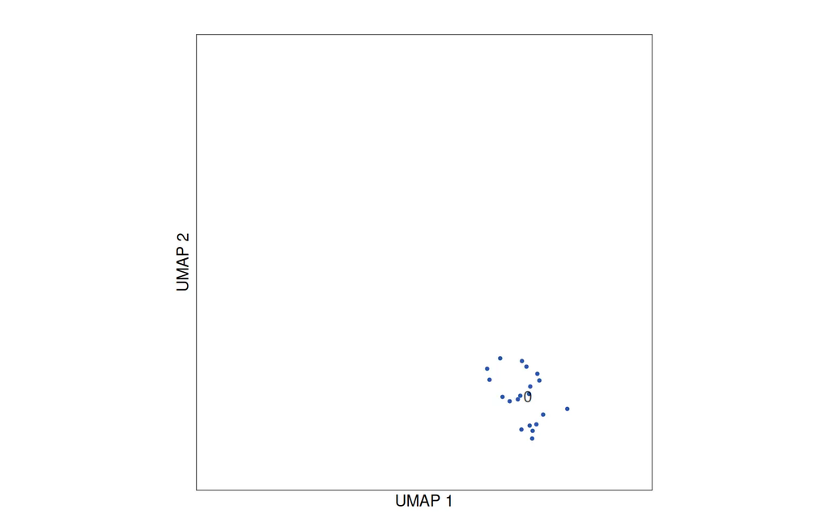

**S4**

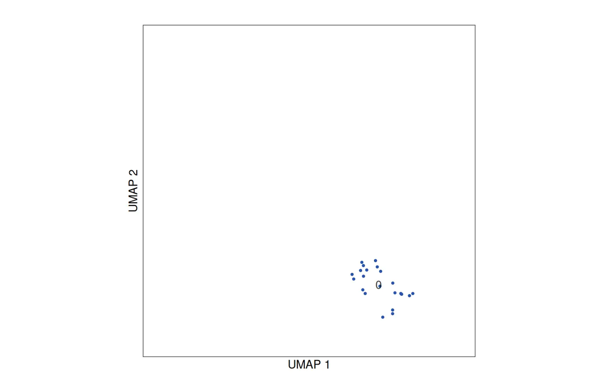

**PCA**

**Combined**

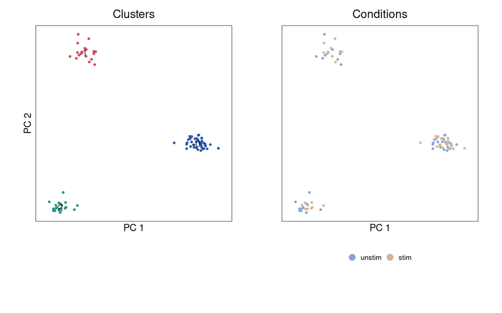

**Samplewise**

**S1**

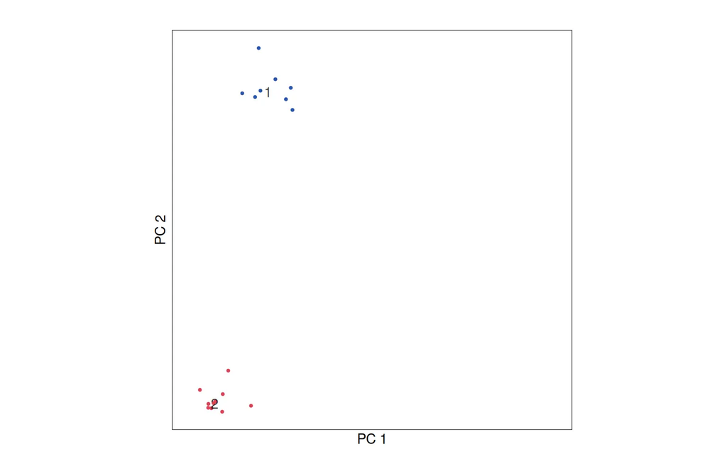

**S2**

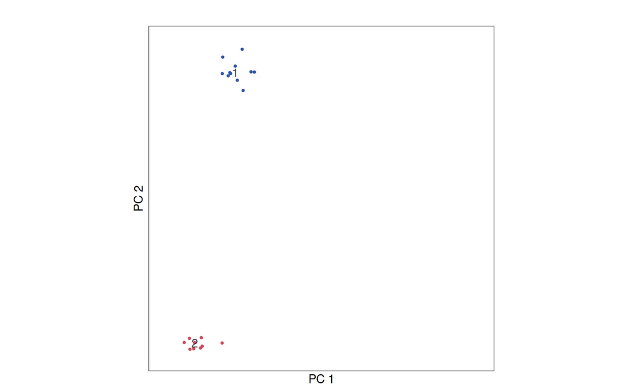

**S3**

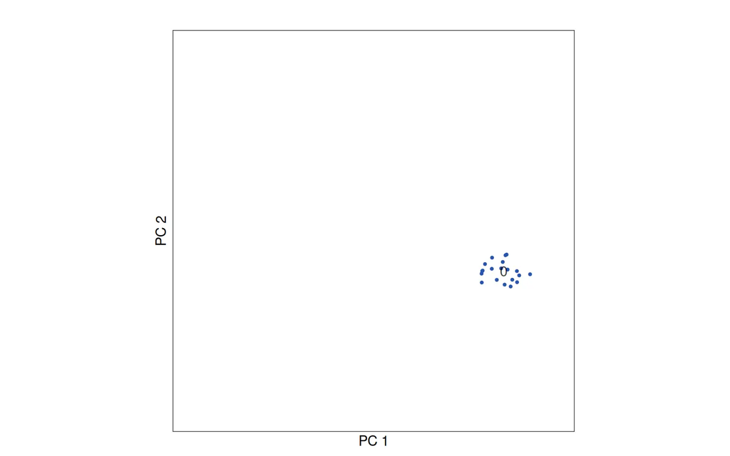

**S4**

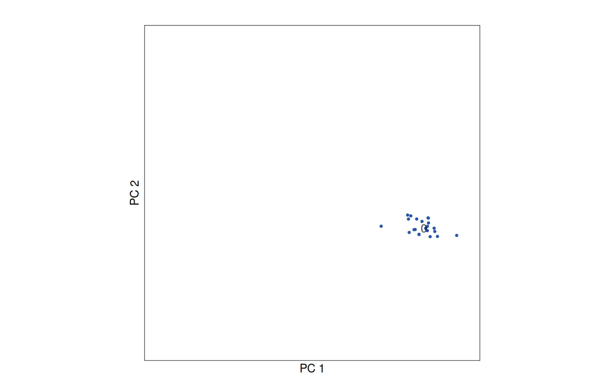

### Cell Annotation

**Warning**

The Proxiome Experiment Summary performs automatic cell annotation by matching each cell’s protein profile to annotated cells in a reference PBMC dataset. These automated labels should be interpreted with caution, particularly when the sample composition differs substantially from the PBMC reference. In such cases, for example in certain stimulated samples or cell lines, the annotations may be unreliable. We therefore recommend performing cell annotation as part of downstream analysis to ensure accurate and context-appropriate results.

**Cell type fractions**

**Figure**

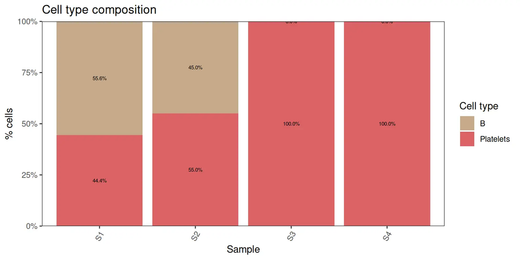

**Table**

| Sample ID | B | Platelets |
| --- | --- | --- |
| S1 | 55.6% | 44.4% |
| S2 | 45.0% | 55.0% |
| S3 | 0.0% | 100.0% |
| S4 | 0.0% | 100.0% |

**S1**

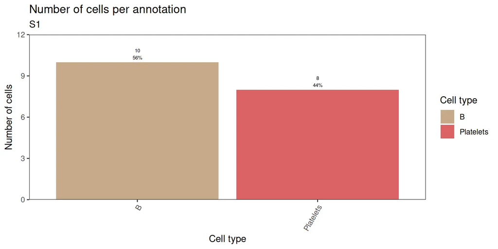

**S2**

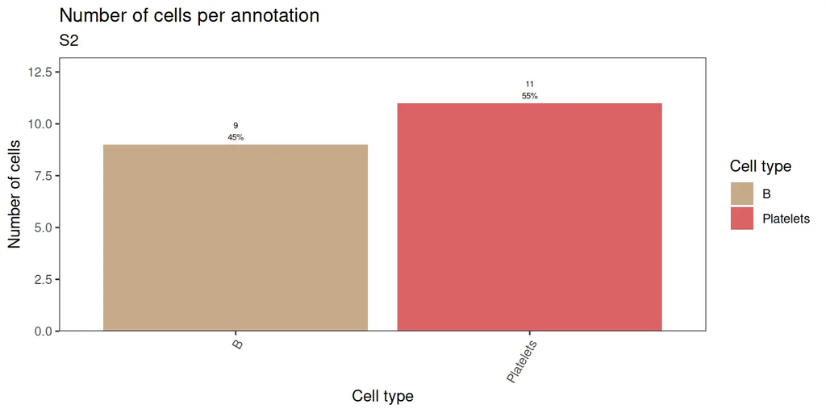

**S3**

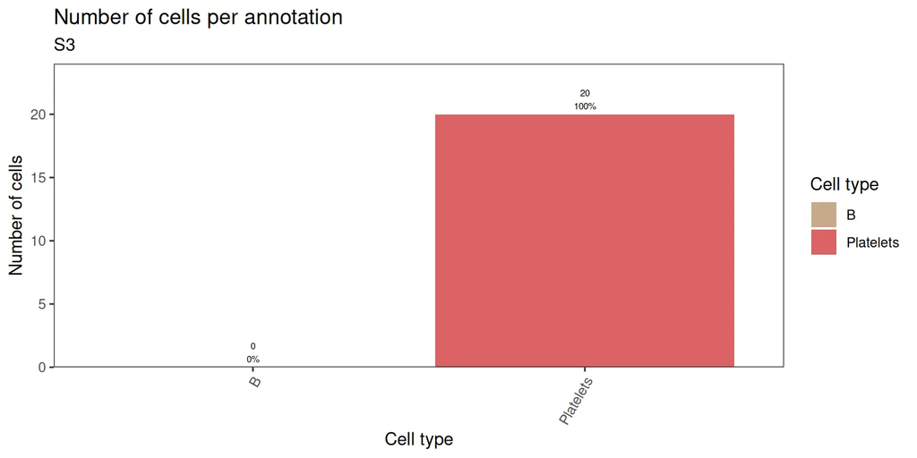

**S4**

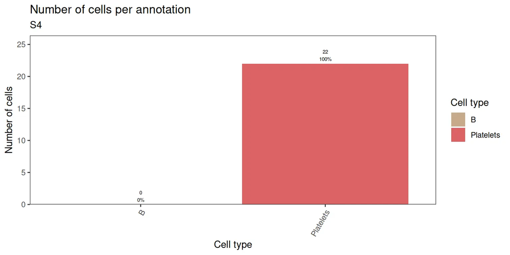